# 📌 Nosso caso de exemplo

**Dados fictícios**

Você foi contratado como gestor de clínica para analisar os dados financeiros e de atendimento dos pacientes. O objetivo é encontrar padrões que possam ajudar na tomada de decisão para melhorar a eficiência da clínica, prever tendências de pagamento e otimizar a gestão financeira. Os dados disponíveis, extraídos do prontuário no formato de planilha, incluem:

- Informações dos pacientes: Nome, sexo, data de nascimento, cidade de origem.
- Detalhes do atendimento: Código do procedimento, nome do profissional, especialidade, data da consulta.
- Detalhes financeiros: Forma de pagamento (Pix, TED, Cartão de Crédito/Débito), valor da venda, número de parcelas.

[Clique para acessar os dados](https://docs.google.com/spreadsheets/d/1YQhDNSt1sOrzq6AKxyYG6wzRAvM-M7l7jJRIHunNB88/copy?gid=1190375422#gid=1190375422)

Os Donos da clínica querem respostas estratégicas para tomar decisões mais inteligentes sobre os atendimentos e pagamentos.

Como novo gestor da clínica é sua chance de explorar os dados e gerar insights úteis! Com base na planilha fornecida, elabore perguntas estratégicas que podem ajudar a clínica a entender melhor seus processos e identificar melhorias.

## 1️⃣ Exemplo de perguntas

🔵 Comparativa (Análise de grupos, rankings, tops, indexação)

- Qual a forma de pagamento mais utilizada?
- Qual profissional gera mais receita para a clínica?
- Algum profissional atende mais pacientes do que os outros?
- Existe uma faixa etária predominante entre os pacientes atendidos?
- Há alguma diferença entre gêneros no volume de atendimentos?
- Quais meses tiveram maior faturamento?

🟢 Histórica (Análise de tendências, PoP, YoY)

- Os pagamentos via Pix aumentaram nos últimos meses?
- Existe um período do ano com mais atendimentos?

🔴 Anomalias (Verificação de outliers, discrepâncias)

- Existem profissionais com variação muito grande no volume de atendimentos mês a mês?
- Há picos inesperados de pagamentos parcelados em determinado período?

🟣 Fatores (Análise de influenciadores principais)

- Pacientes de alguma cidade específica tendem a pagar mais à vista ou parcelado?
- Existe alguma relação entre a especialidade do profissional e o tipo de pagamento escolhido?

🟠 Escalada (Análise de cenários "what if")

- Como a taxa de pagamento parcelado impacta o fluxo de caixa da clínica?
- Se a clínica oferecesse um desconto para pagamentos à vista, como isso afetaria a receita total?

## 2️⃣ Dicionário de dados

| 📌 Nome da Coluna | 🏷️ Tipo de Dado | 📝 Descrição |
| --- | --- | --- |
| **Data_Lancamento** | Data | Data em que a receita foi registrada no sistema. |
| **ID_Atendimento** | Inteiro | Identificação única do atendimento do paciente. |
| **Receita_Codigo** | Inteiro | Código do tipo de receita gerada ou serviço faturado. |
| **Quantidade_Vendida** | Inteiro | Número de unidades do procedimento vendido. |
| **Valor_Venda** | Decimal | Valor total da venda em reais (BRL). |
| **Cliente_ID** | Inteiro | Identificação única do cliente (paciente). |
| **Cliente_Nome** | Texto | Nome do cliente que realizou o procedimento. |
| **Cliente_Sexo** | Texto | Sexo do cliente (M = Masculino, F = Feminino). |
| **Cliente_DataNascimento** | Data | Data de nascimento do paciente. |
| **Cliente_Origem** | Texto | Fonte de aquisição do cliente (Indicação, Google, Redes Sociais, Convênio, etc.). |
| **Cliente_Cidade** | Texto | Cidade onde o cliente reside. |
| **Profissional_Nome** | Texto | Nome do profissional responsável pelo atendimento. |
| **Profissional_Especialidade** | Texto | Especialidade do profissional (ex.: Cirurgia Plástica, Dermatologia). |
| **Data_Pagamento** | Data | Data em que o pagamento foi realizado. |
| **Forma_Pagamento** | Texto | Forma de pagamento utilizada (Pix, TED/DOC, Cartão de Crédito, Cartão de Débito, Boleto, etc.). |

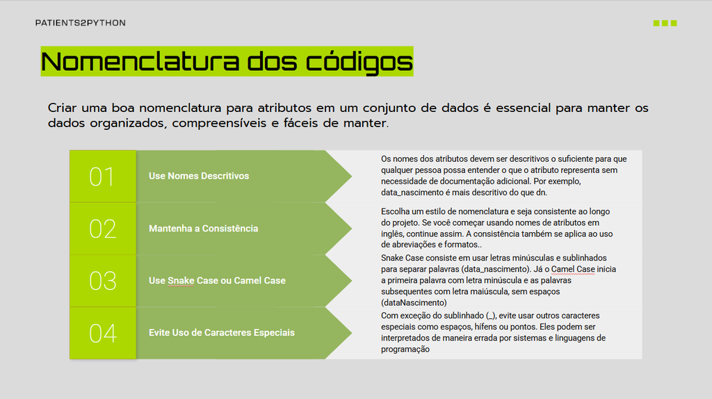

## 3️⃣ Diagrama de relacionamento de entidades

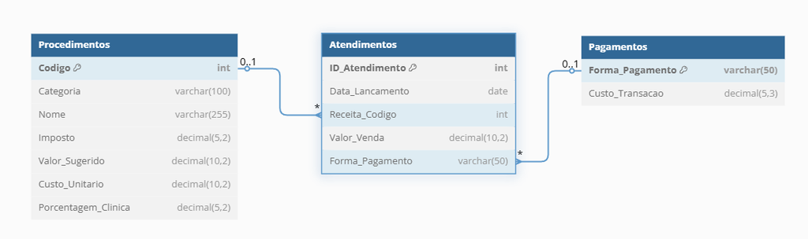

- Atendimentos → Procedimentos (N:1) → Um atendimento pode ter apenas um procedimento, mas um mesmo procedimento pode ser usado em vários atendimentos.
- Atendimentos → Pagamentos (N:1) → Cada atendimento tem uma forma de pagamento associada, mas a tabela de Pagamentos contém apenas os tipos de pagamento disponíveis.